# Data science per psicologi - demo 12.01

Corrado Caudek

2022-03-22

```r
suppressPackageStartupMessages({
  library("here")
  library("tidyverse")
  library("scales")
  library("bayesplot")
  library("distr")
  library("distrEx")
})

theme_set(bayesplot::theme_default(base_size = 12))
bayesplot::color_scheme_set("gray")
set.seed(84735)

knitr::opts_chunk$set(
  collapse = TRUE,
  tidy = 'styler',
  fig.asp = 0.618 # 1 / phi
)
```

# Esercizi sulla distribuzione binomiale

In $\mathsf{R}$, possiamo manipolare le distribuzione di massa o di densità usando quattro funzioni. Tali funzioni iniziano con la seguente lettera:

- `r`: random – si ottiene un campione casuale di osservazioni dalla distribuzione indicata;
- `p`: probability – si ottiene il valore della funzione di ripartizione (l’area nella coda di sinistra) in corrispondenza del quantile indicato;
- `q`: quantile – si ottiene il quantile che corrisponde al valore specificato della funzione di ripartizione;
- `d`: density – si ottiene l’ordinata della funzione di massa di probabilità o di densità di probabilità in corrispondenza del valore indicato della funzione di ripartizione.

## Esercizio 1

Consideriamo una famiglia di cinque figli. Ogni bambino può essere femmina o maschio. Per semplicità supponiamo che $P(femmina) = P(maschio) = 1/2$ e che il genere di ciascun bambino sia indipendentemente da quello degli altri bambini. Sia $X$ il numero di bambine. Allora $X \sim \mbox{Bin}(n = 5, p = 1/2)$. Si trovino $P(X = 2)$ e $P(X <= 2)$. Si fornisca una rappresentazione grafica della distribuzione di massa di probabilità e della funzione di distribuzione della variabile casuale $X = \{0, 1, 2, 3, 4, 5\}$.

La distribuzione di massa di probabilità di $X$ è

```r
dbinom(x = 0:5, size = 5, prob = 0.5)
```

```
## [1] 0.03125 0.15625 0.31250 0.31250 0.15625 0.03125
```

La probabilità $P(X = 2)$ è

```r
dbinom(x = 2, size = 5, prob = 0.5)
```

```
## [1] 0.3125
```

La funzione di ripartizione di $X$ è

```r
cumsum(dbinom(x = 0:5, size = 5, prob = 0.5))
```

```
## [1] 0.03125 0.18750 0.50000 0.81250 0.96875 1.00000
```

Ovvero, usando le funzioni del pacchetto `distr`:

```r
X <- Binom(size = 5, prob = 1 / 2)
p(X)(0:5)
```

```
## [1] 0.03125 0.18750 0.50000 0.81250 0.96875 1.00000
```

Quindi, la probabilità di non più di due femmine, ovvero, $P(X <= 2)$, è

```r
cumsum(dbinom(x = 0:5, size = 5, prob = 0.5))[3]
```

```
## [1] 0.5
```

oppure

```r
dbinom(0, 5, 0.5) + dbinom(1, 5, 0.5) + dbinom(2, 5, 0.5)
```

```
## [1] 0.5
```

oppure

```r
sum(dbinom(0:2, 5, 0.5))
```

```
## [1] 0.5
```

oppure

```r
p(X)(2)
```

```
## [1] 0.5
```

Le variabili casuali create con le funzioni del pacchetto `distr` possono essere rappresentate graficamente usando la funzione `plot()`:

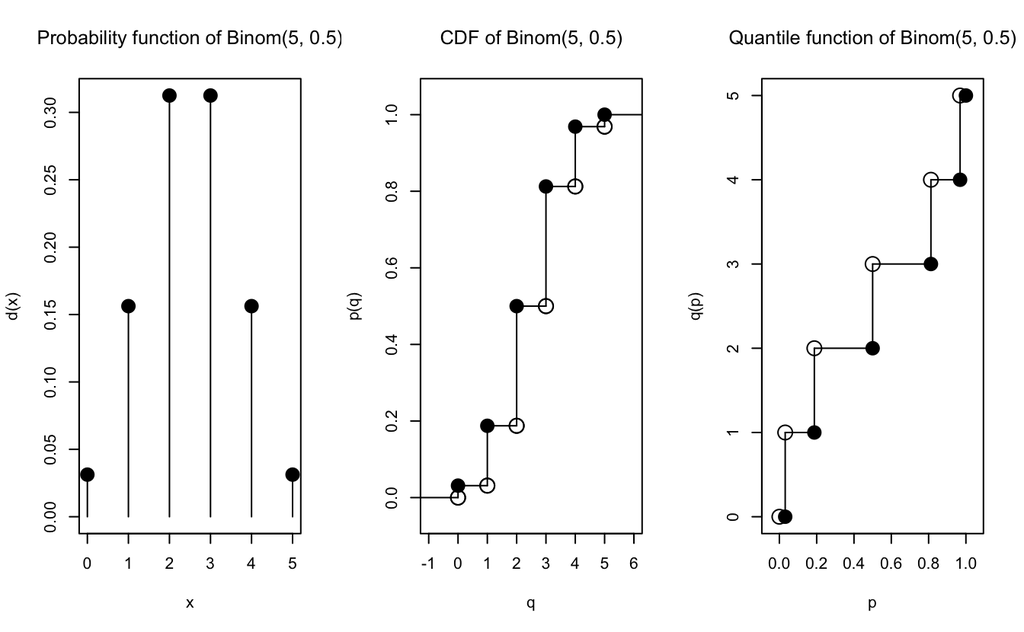

```r
plot(X)
```

ovvero

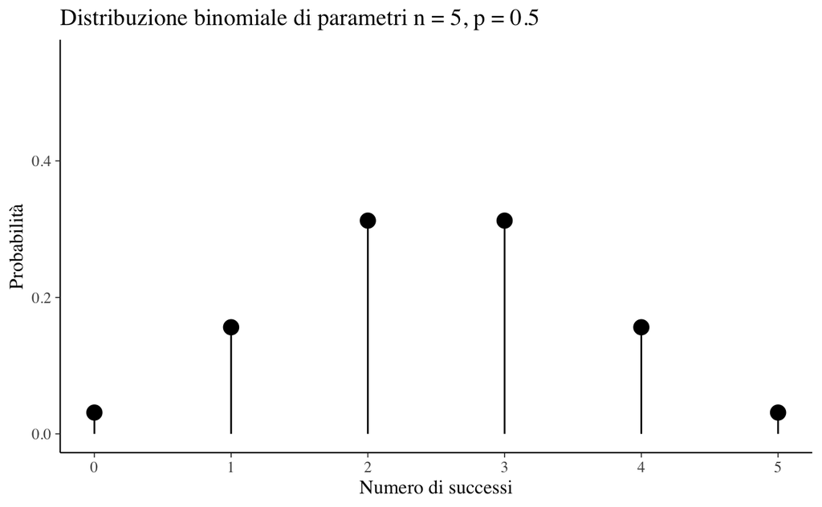

```r
tibble(
  y = 0:5,
  py = dbinom(0:5, 5, 0.5)
) %>%
  ggplot(aes(y, py)) +
  geom_point(size = 4) +
  geom_linerange(aes(x = y, ymax = py, ymin = 0.0)) +
  ylim(0, 0.55) +
  labs(
    title = "Distribuzione binomiale di parametri n = 5, p = 0.5",
    x = "Numero di successi",
    y = "Probabilità"
  )
```

## Esercizio 2

Calcoliamo il valore atteso e la varianza della variabile casuale $X$ definita nel’esercizio 1.

Svolgendo i calcoli, per il valore atteso troviamo:

```r
x <- 0:5
px <- dbinom(x = 0:5, size = 5, prob = 0.5)
sum(x * px)
```

```
## [1] 2.5
```

Questo risultato si replica usando le funzioni del pacchetto `distrEx`:

```r
X <- Binom(size = 5, prob = 0.5)
E(X)
```

```
## [1] 2.5
```

Calcoliamo ora la varianza:

```r
sum(x^2 * px) - (sum(x * px))^2
```

```
## [1] 1.25
```

oppure

```r
var(X)
```

```
## [1] 1.25
```

La deviazione standard si trova con

```r
sqrt(sum(x^2 * px) - (sum(x * px))^2)
```

```
## [1] 1.118034
```

oppure con

```r
sd(X)
```

```
## [1] 1.118034
```

## Esercizio 3

```r
dbinom(17, size = 31, prob = 0.447)
```

```
## [1] 0.07532248
```

```r
pbinom(13, size = 31, prob = 0.447)
```

```
## [1] 0.451357
```

```r
pbinom(11, size = 31, prob = 0.447, lower.tail = FALSE)
```

```
## [1] 0.8020339
```

```r
pbinom(14, size = 31, prob = 0.447, lower.tail = FALSE)
```

```
## [1] 0.406024
```

```r
sum(dbinom(16:19, size = 31, prob = 0.447))
```

```
## [1] 0.2544758
```

oppure

```r
diff(pbinom(c(19, 15), size = 31, prob = 0.447, lower.tail = FALSE))
```

```
## [1] 0.2544758
```

```r
X <- Binom(size = 31, prob = 0.447)
E(X)
```

```
## [1] 13.857
```

```r
var(X)
```

```
## [1] 7.662921
```

```r
sd(X)
```

```
## [1] 2.768198
```

```r
E(4 * X + 51.324)
```

```
## [1] 106.752
```